# Vinhetas

A documentação de um pacote é indispensável para sua criação e distribuição. Tecnicamente falando, não tem como fazer um pacote R sem documentação para os objetos exportados. Por mais breve que seja, a documentação precisa existir para o pacote ser construído e, portanto, a documentação é uma exigência.

Os usuários consultam a documentação quando sabem exatamente o que procurar. Exceto pela sessão *Exemplos*, a documentação não se destina a mostrar a conexão entre funções ou seu uso coordenado para solução de certos problemas. Isso porque as páginas de ajuda descrevem objetos individualmente, ou em grupos pequenos, fornecendo uma orientação específica e não uma visão geral e integrada.

No primeiro contato com um pacote, por outro lado, o que o usuário deseja é de uma visão geral dele, uma espécie de trailer ou enredo. A documentação é teodiosa de ler para alguém que quer uma visão geral, pois ela é como uma descrição de cada personagem e não da forma como eles se envolvem.

A palavra *vignette* admite traduções como vinheta, esboço e epsódio. No contexto de um pacote R, uma vinheta é uma documentação auxiliar do mesmo que descreve o uso coordenado das funções que contém (ou *datasets*) na solução de um problema ou sobre um tema. É usada para dar uma visão geral dos recusos do pacote.

As vinhetas não são exigidas nos pacotes, embora seja a melhor forma de apresentá-lo. Certamente pela mesma razão, não existe restrição de tamanho nem forma e fica como responsabilidade dos autores usar do bom senso e criatividade ao escrever suas vinhetas. Se um pacote é multitemático ou se a solução para diferentes problemas são longas, é melhor ter vinhetas dedicadas a cada um.

O que é marcante, no entanto, é que as vinhetas fazem mistura de prosa e código. Antes da versão 3.0.0 do R, as vinhetas eram documentos Sweave e nas versões mais recentes, vinhetas não Sweave foram permitidas.

Sendo ou não documentos Sweave, nas vinhetas são permitidos gráficos e outputs de resultados R, além de tabelas e equações. As vinhetas em HTML, consideradas a partir da versão 3.0.0, podem até mesmo ter vídeos, animações em gif, gráficos em JavaScript e OpenGL.

Diante de todos esses recursos que uma vinheta pode conter e pelo excelente meio de divulgação do pacote que é, nesse capítulo serão descritos os passos para adicionar vinhetas ao pacote. Vamos considerar vinhetas em HTML e PDF escritas em RMarkDown e compiladas com o knitr.

# Consultar vinhetas

## Pacotes instalados

Certamente alguns dos pacotes que você tem instalado possuem vinheta. Se você está reproduzindo o código desse tutorial, então você tem o `devtools` e o `roxygen2`. Para acessar as vinhetas disponíveis você pode usar as opções ilustradas abaixo.

```r
# Exibe todas as vinhetas disponíveis no console.
vignette()

# Exibe as vinhetas de um único pacote no console.
vignette(package = "roxygen2")

# Abre uma vinheta pelo nome (essa é do pacote roxygen2).
vignette(topic = "rd")
vignette(topic = "rd", package = "roxygen2")

# Exibe todas as vinhetas disponíveis no navegador.
browseVignettes()

# Exibe apenas as vinhetas de um pacote.
browseVignettes(package = "roxygen2")
```

## Pacotes oficiais no CRAN

Para os pacotes que são oficiais (que estão no CRAN), você pode consultar as vinhetas e a documentação online. Os pacotes estão no endereço `https://cran.r-project.org/web/packages/<pacote>/index.html`, em que `<pacote>` é um nome. Nessas páginas existe uma seção com URLs para as vinhetas, quando disponíveis, logo abaixo da documentação em PDF.

Nós fizemos um *web scraping* no site do CRAN e verificamos que 22.5% dos pacotes oficiais do R tem pelo menos uma vinheta, sendo que 17.2% tem apenas uma e 5.4% tem mais que uma, conforme a Figura .

Existe um total de 2654 distribuídas em 7727 pacotes, o que dá uma média de 0.34 vinhetas por pacote. Esse *web scrap* levou 150 minutos e foi feito no dia 04 de Janeiro de 2016.

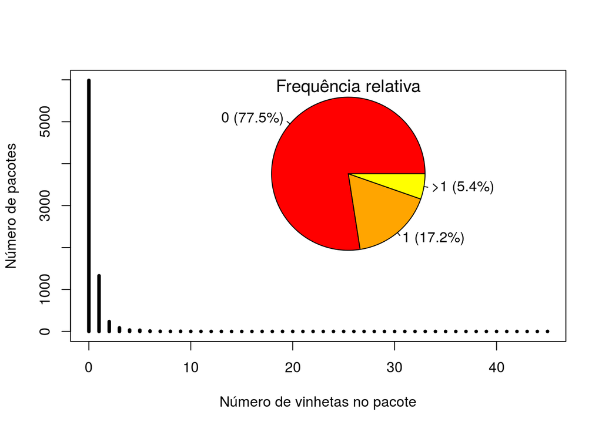

Distribuição do número de vinhetas por pacote nospacotes oficiais do R disponíveis no CRAN.

Além dos pacotes oficiais existem pacotes em desenvolvimento no GitHub, por exemplo, cuja vinheta pode também estar disponível. Esse é o caso do pacote [breedR](https://github.com/famuvie/breedR/tree/master/inst/doc).

Fica aqui aquela pergunta tipo Tostines: um pacote tem mais vinhetas por que é mais usado ou é mais usado por que tem mais vinhetas?

# Criando a vinheta

Produzir a vinheta de um pacote é tão fácil quanto as demais partes dele. O pacote *devtools* também possui os recursos para trabalharmos com as vinhetas, desde a criação até a inclusão dela como componente do pacote, etapas que veremos a seguir.

Antes disso, no entanto, vale comentar que as vinhetas são mais facilmente escritas se você considerar [RMarkDown](http://rmarkdown.rstudio.com/), embora isso não seja uma exigência. As vinhetas podem ser escritas em LaTex entrelaçado com R, queremos dizer, tanto da forma antiga com o [Sweave](https://www.statistik.lmu.de/~leisch/Sweave/) ou da forma mais recente com o [knitr](http://yihui.name/knitr/). A vantagem de escrever em MarkDown é a velocidade, praticidade e poder obter vinhetas em HTML e PDF ao mesmo tempo facilmente.

O Hadley mantem uma ampla documentação sobre [produção de vinhetas](http://r-pkgs.had.co.nz/vignettes.html), com o qual nos baseamos para expor o que vem a seguir.

O comando `use_vignette()` é quem cria a estrutura necessária para acomodar uma vinheta com os devidos cuidados. Ao executá-lo, é criado o diretório `vignettes/` com um arquivo `.Rmd` e, além disso, ele adiciona ao campo `Suggests` no `DESCRIPTION` os pacotes `knitr` e `rmarkdown`, necessários para gerar a vinheta.

```r
library(devtools)

# Cria a primeira vinheta do pacote.
use_vignette("minhaVinheta1")
```

```
Draft vignette created in /home/walmes/repos/prr/meupacote/vignettes/minhaVinheta1.Rmd
```

```
./meupacote/
|-- DESCRIPTION
|-- man
|   |-- pitagoras.Rd
|   `-- plotTriRet.Rd
|-- NAMESPACE
|-- R
|   |-- pitagoras.R
|   `-- plotTriRet.R
`-- vignettes
    `-- minhaVinheta1.Rmd
```

```
Package: meupacote
Title: Meu Primeiro Pacote R
Version: 0.0-1
Authors@R: as.person(c(
    "Fernando de Pol Mayer <fernando.mayer@ufpr.br> [aut,cre]",
    "Walmes Marques Zeviani <walmes@ufpr.br> [aut]"))
Description: Esse é o primeiro pacoteque estamos fazendo. Nesse tutorial
    o pacote será desenvolvido com funções, dados e vinheta.
License: GPL-3
URL: http://git.leg.ufpr.br/leg/prr
BugReports: http://git.leg.ufpr.br/leg/prr/issues
LazyData: true
Encoding: UTF-8
Depends:
    R (>= 3.2.3)
Imports: lattice
Suggests: knitr,
    rmarkdown
VignetteBuilder: knitr
```

O arquivo `Rmd` é criado já com conteúdo para poder orientá-lo. No topo do arquivo tem uma parte de meta dados escrita em YAML (*yet another markup language*) que detalha as informações do documento e definem o processo de sua criação.

```
---
title: "Vignette Title"
author: "Vignette Author"
date: "`r Sys.Date()`"
output: rmarkdown::html_vignette
vignette: >
  %\VignetteIndexEntry{Vignette Title}
  %\VignetteEngine{knitr::rmarkdown}
  %\VignetteEncoding{UTF-8}
---
```

```
## Meta dados de uma vinheta.
% \VignetteIndexEntry{}      ## Título no index.html
% \VignetteDepends{}         ## Pacotes do qual depende
% \VignetteKeyword{palavra1} ## Palavras-chave.
% \VignetteKeyword{palavra2}
```

Edite à vontade esse arquivo fazendo a melhor propaganda possível do seu pacote. Tome cuidado com os pacotes que a sua vinheta vai usar. É comum as vinhetas chamarem pacotes para fazer gráficos, como o `lattice`, `ggplot2` e `plotrix`. É indicado que eles estejam nos campos do seu `DESCRIPTION`, se não no `Imports`, pelo menos no `Suggests`.

## Vinhetas em HTML

```r
opts_chunk$set(eval = FALSE)
```

Para produzir a vinheta, use o comando `build_vignettes()`. Ele vai gerar as vinhetas de cada arquivo e levá-las para outro diretório, como pode ser visto abaixo. Caso você não tenha um dos seguintes pacotes: `evaluate`, `formatR`, `highr`, `knitr`, `mime`, `stringi`; será necessário instalá-los.

```r
build_vignettes()
```

[output not shown]

Por fim, basta executar `check()` e `build()` mais uma vez para incluir as vinhetas no `.tar.gz` do seu pacote.

## Vinhetas em PDF

As vinhetas ficam no `inst/doc/` quando o pacote é instalado. Os fontes ficam em `vignettes/`

Elas ficam no diretório `vignettes/`. São parte do sistema de ajuda/documentação do pacote.

`R CMD check` ou `devtools::check()` avalia as vinhetas, extrai o código e avalia sua execussão sequêncial, chunk por chunk.

`R CMD build` vai criar o PDF ou HTML da vinheta e colocar no `inst/doc/`, para isso vai rodar a engine declarada (knitr ou Sweave, rmarkdown, enfim).

A partir da versão 3.0.0, o R admite vignettes engines diferentes do Sweave. No caso, permite usar o **knitr** para gerar PDF e HTML.